# Neural Networth

## Reddit Comments Sentiment Analysis to identify correlation (if any) with Bitcoin Prices

```python
import praw
import pandas as pd
import datetime as dt
from praw.models import MoreComments

df = {          "author":[], \
                "body":[], \
                "created_utc":[], \
                "id":[], \
                "parent_id":[], \
                "permalink":[], \
                "score":[],\
                "subreddit":[],\
                "subreddit_id":[]
     }


reddit = praw.Reddit(client_id='rQyKT1UK10Amag',\
                     client_secret = 'FDx7XvDPdHr5k0b5q6ep3Nqyv2o', \
                     user_agent='Neural Networth', \
                     username='WanderingMysticism', \
                     password='Rasengan@1292')

subreddit=reddit.subreddit('Bitcoin')

#This pulls the last 5000 posts within the category top that Reddit creates
top_subreddit=subreddit.top(limit=5000)

for submissions in top_subreddit:
    submission_comment=reddit.submission(id=submissions.id)
    submission_comment.comments.replace_more(limit=5)
    for top_level_comment in submission_comment.comments:
        df["author"].append(top_level_comment.author)
        df["body"].append(top_level_comment.body)
        df["created_utc"].append(top_level_comment.created_utc)
        df["id"].append(top_level_comment.id)
        df["parent_id"].append(top_level_comment.parent_id)
        df["permalink"].append(top_level_comment.permalink)
        df["score"].append(top_level_comment.score)
        df["subreddit"].append(top_level_comment.subreddit)
        df["subreddit_id"].append(top_level_comment.subreddit_id)
```

```python
import pandas as pd
df1=pd.DataFrame(df)
```

```python
df1=df1.drop('Unnamed: 0',axis=1)
df1.to_csv('Updated_Comments.csv')
```

### WordCloud(Reddit)

```python
import pandas as pd
import matplotlib.pyplot as plt
%matplotlib inline
from wordcloud import WordCloud, STOPWORDS

MIN_LENGTH=4
DELETE_WORDS=[]

def remove_words(text_string,DELETE_WORDS=DELETE_WORDS):
    for word in DELETE_WORDS:
        text_string = text_string.replace(word,'')
    return text_string


def remove_short_words(text_string,min_length = MIN_LENGTH):
    word_list = text_string.split()
    for word in word_list:
        if len(word) < min_length:
            text_string = text_string.replace(' '+word+' ',' ',1)
    return text_string

# string together all comments from 'body' columns to prepare for Word Cloud
all_comments = ''
for i in df_reddit['body']:
    i = remove_words(i)
    i = remove_short_words(i)
    all_comments=all_comments+str(i)

# begin WordCloud setup
import gensim.summarization
reddit_wordcloud = gensim.summarization.summarize(all_comments, word_count=100)
```

## Create the Bitcoin CSV Files from master file

```python
import pandas as pd
btc=pd.read_csv('bitcoin-historical-data/coinbase.csv')
```

```python
btc['date']=pd.to_datetime(btc['Timestamp'],unit='s')
```

```python
btc.head(10)
btc=btc.rename(index=str,columns={'Unnamed: 0':'Index'})
```

```python
def convert_year(dt):
    year=dt.year
    return year

btc['year']=btc['date'].apply(convert_year)
```

```python
btc1=btc[btc['year']==2016]
btc1.to_csv('btc_subset_2016.csv',header=True)
```

```python
btc1=btc[btc['year']==2017]
btc1.to_csv('btc_subset_2017.csv',header=True)
```

```python
btc1=btc[btc['year']==2018]
btc1.to_csv('btc_subset_2017.csv',header=True)
```

# FRESH RUN

## Read the scraped data into a DataFrame

```python
import pandas as pd
df=pd.read_csv('Updated_Comments.csv')
```

## Clean data to remove NaNs and drop irrelevant columns

```python
df['Date']=pd.to_datetime(df['created_utc'],unit='s')
```

```python
df=df.dropna(how='any')
df=df.drop('Unnamed: 0',axis=1)
```

```python
import datetime as dt
df['DateTime']=df['Date'].dt.strftime('%m/%d/%Y')
```

```python
df=df.sort_values(by='Date')
```

## Define Function to identify sentiments

```python
def get_nrc_data():
    nrc = "NRC-Emotion-Lexicon-Wordlevel-v0.92.txt"
    count=0
    emotion_dict=dict()
    with open(nrc,'r') as f:
        all_lines = list()
        for line in f:
            if count < 46:
                count+=1
                continue
            line = line.strip().split('\t')
            if int(line[2]) == 1:
                if emotion_dict.get(line[0]):
                    emotion_dict[line[0]].append(line[1])
                else:
                    emotion_dict[line[0]] = [line[1]]
    return emotion_dict

def emotion_analyzer(text,emotion_dict=get_nrc_data()):
    #Set up the result dictionary
    emotions = {x for y in emotion_dict.values() for x in y}
    emotion_count = dict()
    for emotion in emotions:
        emotion_count[emotion] = 0

    #Analyze the text and normalize by total number of words
    total_words = len(text.split())
    for word in text.split():
        if emotion_dict.get(word):
            for emotion in emotion_dict.get(word):
                emotion_count[emotion] += 1/len(text.split())
    return emotion_count

def comparative_emotion_analyzer(text_tuples,object_name="Crypto",print_output=False):
    if print_output:
        print("%-20s %1s\t%1s %1s %1s %1s   %1s %1s %1s %1s"%(object_name,
                                                              "fear","trust","negative","positive",
                                                              "joy","disgust","anticip", "sadness",
                                                              "surprise"))
    import pandas as pd
    df = pd.DataFrame(columns=[object_name,'Fear','Trust','Negative',
                           'Positive','Joy','Disgust','Anticipation',
                           'Sadness','Surprise'],)
    df.set_index(object_name,inplace=True)

    output = df
    for text_tuple in text_tuples:
        text = text_tuple[1]
        result = emotion_analyzer(text)
        if print_output:
            print("%-20s %1.2f\t%1.2f\t%1.2f\t%1.2f\t%1.2f\t%1.2f\t%1.2f\t%1.2f\t%1.2f"%(
                text_tuple[1][0:20],result['fear'],result['trust'],
                  result['negative'],result['positive'],result['joy'],result['disgust'],
                  result['anticipation'],result['sadness'],result['surprise']))
        df.loc[text_tuple[0]] = [result['fear'],result['trust'],
                  result['negative'],result['positive'],result['joy'],result['disgust'],
                  result['anticipation'],result['sadness'],result['surprise']]
    return output
#And test it
#comparative_emotion_analyzer([('community',community),('le_monde',le_monde)])
```

## Aggregate Comments per Day for all the Reddit Comments

```python
def text_aggregate(text_df):
    text=''
    for i in range(len(text_df)):
        m = str(text_df.iloc[i])
        text=text+' '+m

    return text.lower()
```

```python
import pandas as pd
import numpy as np

final_list=list()

for i in df['DateTime'].unique():
    row_list=list()
    t=df[df['DateTime']==i]
    text=text_aggregate(t)
    row_list.append(i)
    row_list.append(text)
    final_list.append(tuple(row_list))
```

```python
time_series_analysis=comparative_emotion_analyzer(final_list,object_name='Bitcoin')
time_series_analysis.reset_index(level=0, inplace=True)
```

## Correlation Data

```python
time_series_analysis.corr()
```

|  | Fear | Trust | Negative | Positive | Joy | Disgust | Anticipation | Sadness | Surprise |
| --- | --- | --- | --- | --- | --- | --- | --- | --- | --- |
| Fear | 1.000000 | 0.036308 | 0.424878 | -0.005209 | -0.018630 | 0.482940 | 0.046140 | 0.601367 | -0.032362 |
| Trust | 0.036308 | 1.000000 | -0.024246 | 0.746913 | 0.587402 | 0.137712 | 0.462739 | -0.043760 | 0.440995 |
| Negative | 0.424878 | -0.024246 | 1.000000 | -0.039100 | 0.022471 | 0.549362 | 0.050892 | 0.542411 | 0.016840 |
| Positive | -0.005209 | 0.746913 | -0.039100 | 1.000000 | 0.701789 | 0.157204 | 0.516241 | -0.049416 | 0.532446 |
| Joy | -0.018630 | 0.587402 | 0.022471 | 0.701789 | 1.000000 | 0.236124 | 0.701483 | -0.028526 | 0.735952 |
| Disgust | 0.482940 | 0.137712 | 0.549362 | 0.157204 | 0.236124 | 1.000000 | 0.132139 | 0.582407 | 0.280787 |
| Anticipation | 0.046140 | 0.462739 | 0.050892 | 0.516241 | 0.701483 | 0.132139 | 1.000000 | -0.041877 | 0.645073 |
| Sadness | 0.601367 | -0.043760 | 0.542411 | -0.049416 | -0.028526 | 0.582407 | -0.041877 | 1.000000 | -0.008287 |
| Surprise | -0.032362 | 0.440995 | 0.016840 | 0.532446 | 0.735952 | 0.280787 | 0.645073 | -0.008287 | 1.000000 |

```python
time_series_analysis1=time_series_analysis
time_series_analysis1['Date']=pd.to_datetime(time_series_analysis1['Bitcoin'],errors='coerce')
```

## Subset Data to run the code in relevant ranges (which was identified by looking at peaks) on plotting all the sentiments over time. We focus on days between '2017-06-01' and '2018-06-25'

```python
time_series_analysis1=time_series_analysis1[time_series_analysis1['Date']>'2017-06-01']
time_series_analysis1=time_series_analysis1[time_series_analysis1['Date']<'2018-06-25']
time_series_analysis1.head()
```

|  | Bitcoin | Fear | Trust | Negative | Positive | Joy | Disgust | Anticipation | Sadness | Surprise | Date |
| --- | --- | --- | --- | --- | --- | --- | --- | --- | --- | --- | --- |
| 2 | 01/01/2018 | 0.003612 | 0.034312 | 0.004966 | 0.066817 | 0.033183 | 0.002032 | 0.034763 | 0.002032 | 0.031603 | 2018-01-01 |
| 4 | 01/02/2018 | 0.001189 | 0.033591 | 0.004459 | 0.066885 | 0.032996 | 0.001189 | 0.034185 | 0.001784 | 0.032402 | 2018-01-02 |
| 6 | 01/03/2018 | 0.001955 | 0.040282 | 0.003715 | 0.075870 | 0.041650 | 0.000782 | 0.043410 | 0.002151 | 0.034806 | 2018-01-03 |
| 8 | 01/04/2018 | 0.000609 | 0.034301 | 0.002436 | 0.067587 | 0.032880 | 0.000203 | 0.034301 | 0.000609 | 0.032271 | 2018-01-04 |
| 11 | 01/05/2018 | 0.001425 | 0.036125 | 0.006207 | 0.070113 | 0.035616 | 0.000814 | 0.035311 | 0.001628 | 0.033886 | 2018-01-05 |

## BITCOIN DATA

### Read in the Bitcoin Subset files (which had been created earlier)

```python
btc1=pd.read_csv('btc_subset_2016.csv')
btc2=pd.read_csv('btc_subset_2017.csv')
btc3=pd.read_csv('btc_subset_2018.csv')
```

```python
btc1 = btc1[['Weighted_Price','date']]
btc2 = btc2[['Weighted_Price','date']]
btc3 = btc3[['Weighted_Price','date']]

btc1['date'] = pd.to_datetime(btc1['date'])
btc2['date'] = pd.to_datetime(btc2['date'])
btc3['date'] = pd.to_datetime(btc3['date'])

btc1 = btc1.set_index('date')
btc2 = btc2.set_index('date')
btc3 = btc3.set_index('date')

btc_all = pd.concat([btc1,btc2,btc3])
btc_all.dropna(how='any')
btc_all=btc_all.reset_index()
```

```python
btc_all1 = btc_all[btc_all['date']>'2017-06-01']
btc_all1 = btc_all1[btc_all1['date']<'2018-06-25']
btc_all1.head(10)
```

|  | date | Weighted_Price |
| --- | --- | --- |
| 744481 | 2017-06-01 00:01:00 | 2303.493691 |
| 744482 | 2017-06-01 00:02:00 | 2303.787616 |
| 744483 | 2017-06-01 00:03:00 | 2303.119788 |
| 744484 | 2017-06-01 00:04:00 | 2305.855474 |
| 744485 | 2017-06-01 00:05:00 | 2307.564452 |
| 744486 | 2017-06-01 00:06:00 | 2309.615571 |
| 744487 | 2017-06-01 00:07:00 | 2309.946644 |
| 744488 | 2017-06-01 00:08:00 | 2309.854463 |
| 744489 | 2017-06-01 00:09:00 | 2309.525830 |
| 744490 | 2017-06-01 00:10:00 | 2303.248144 |

## EMOTION AND PRICE GRAPHS

[figure not shown]

```python
#Plotting all negative emotions together

import seaborn as sns
sns.set(style="darkgrid")
import matplotlib.pyplot as plt

emotions = ['Negative','Fear','Disgust','Sadness']

plt.figure(figsize=(15,15))

sns.set(style="white", palette="muted", color_codes=True)

for i in emotions:
    sns.lineplot(x="Date", y=i,
                 data=time_series_analysis1)
plt.legend(emotions)

# sns.lineplot(x="Iden_Key", y="Weighted_Price",
#              data=btc8)

plt.xlabel('TimeStamps')
plt.ylabel('Emotion Score')
plt.title('Negative Emotion Score')
plt.show()
```

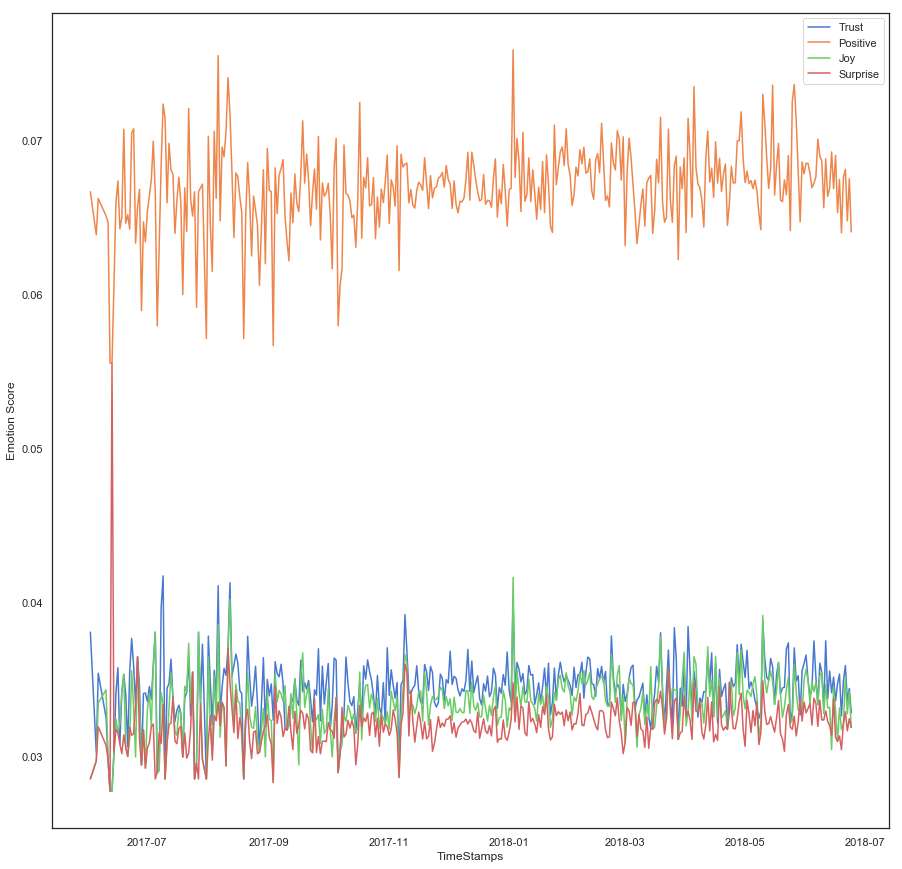

```python
#Plotting all positive emotions
import seaborn as sns
sns.set(style="darkgrid")
import matplotlib.pyplot as plt

emotions = ['Trust','Positive','Joy','Surprise']

plt.figure(figsize=(15,15))

sns.set(style="white", palette="muted", color_codes=True)

for i in emotions:
    sns.lineplot(x="Date", y=i,
                 data=time_series_analysis1)
plt.legend(emotions)
plt.ylabel('Emotion Score')

plt.xlabel('TimeStamps')

plt.show()
```

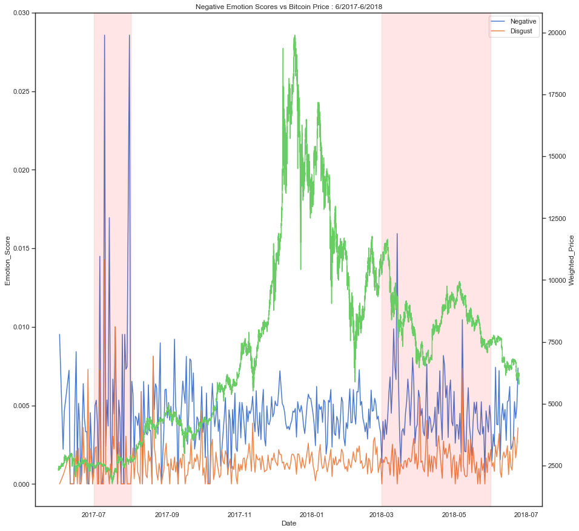

```python
#Plotting difference in emotions with bitcoin price
import seaborn as sns
sns.set(style="darkgrid")
import matplotlib.pyplot as plt

emotions = ['Negative','Disgust']

plt.figure(figsize=(15,15))

sns.set(style="white", palette="muted", color_codes=True)

for i in emotions:
    sns.lineplot(x="Date", y=i,
                 data=time_series_analysis1)
plt.legend(emotions)
plt.ylabel('Emotion_Score')
ax2 = plt.twinx()

sns.lineplot(x="date", y="Weighted_Price",
             data=btc_all1,color='g')

plt.xlabel('TimeStamps')
plt.axvspan('2017-07-01', '2017-08-01', color='red', alpha=0.1)
plt.axvspan('2018-03-01', '2018-06-01', color='red', alpha=0.1)
plt.title('Negative Emotion Scores vs Bitcoin Price : 6/2017-6/2018')
plt.savefig('Negative-BitcoinPrice.png')
plt.show()
```

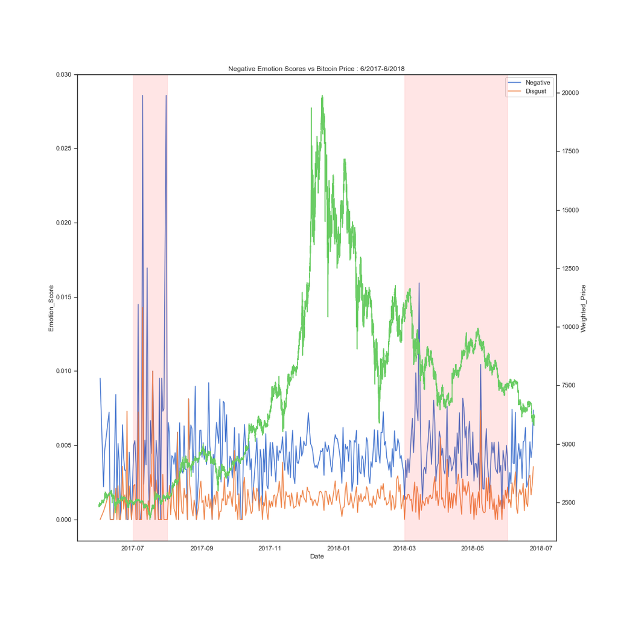

```python
from IPython.display import Image
Image(filename="Negative-BitcoinPrice.png",height=800,width=800)
```

# Note:

## As indiciated by the graph, the drop in Bitcoin prices corresponds to certain upticks in Negative Comments in Reddit

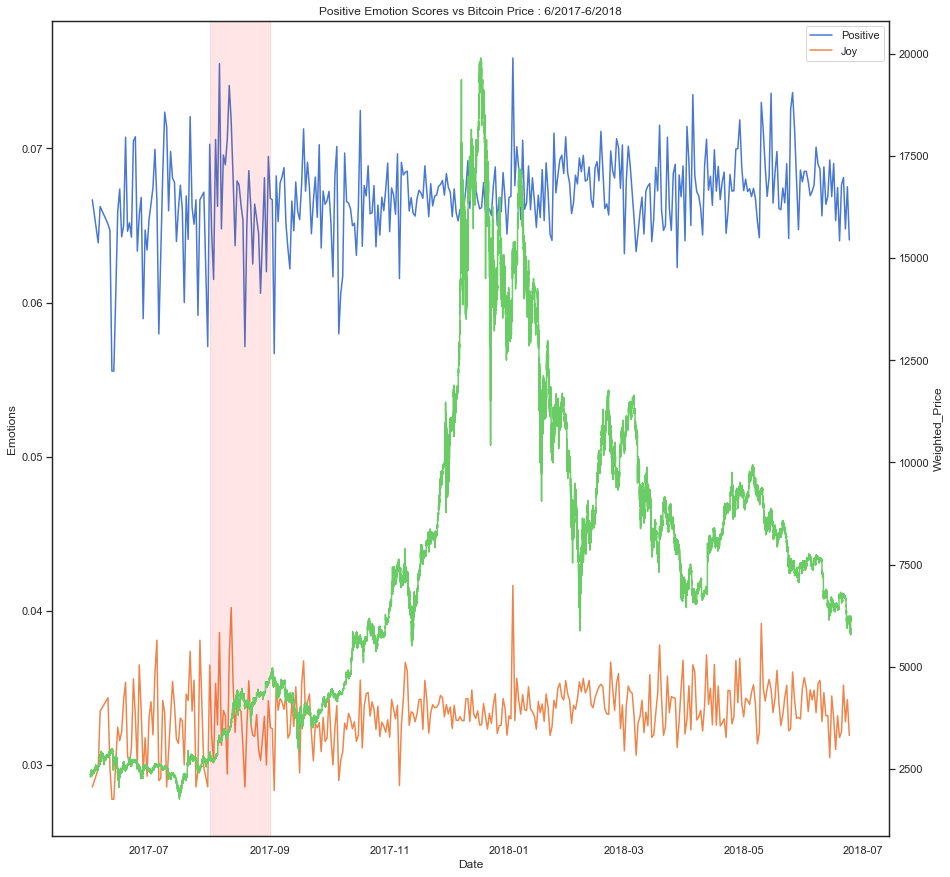

```python
#Plotting difference in emotions with bitcoin price

import seaborn as sns
sns.set(style="darkgrid")
import matplotlib.pyplot as plt

emotions = ['Positive','Joy']

plt.figure(figsize=(15,15))

sns.set(style="white", palette="muted", color_codes=True)

for i in emotions:
    sns.lineplot(x="Date", y=i,
                 data=time_series_analysis1)
plt.legend(emotions)
plt.ylabel('Emotions')
ax2 = plt.twinx()

sns.lineplot(x="date", y="Weighted_Price",
             data=btc_all1,color='g')

plt.xlabel('TimeStamps')
plt.axvspan('2017-08-01', '2017-09-01', color='red', alpha=0.1)
plt.title('Positive Emotion Scores vs Bitcoin Price : 6/2017-6/2018')
plt.savefig('Positive-BitcoinPrice.png')
plt.show()
```

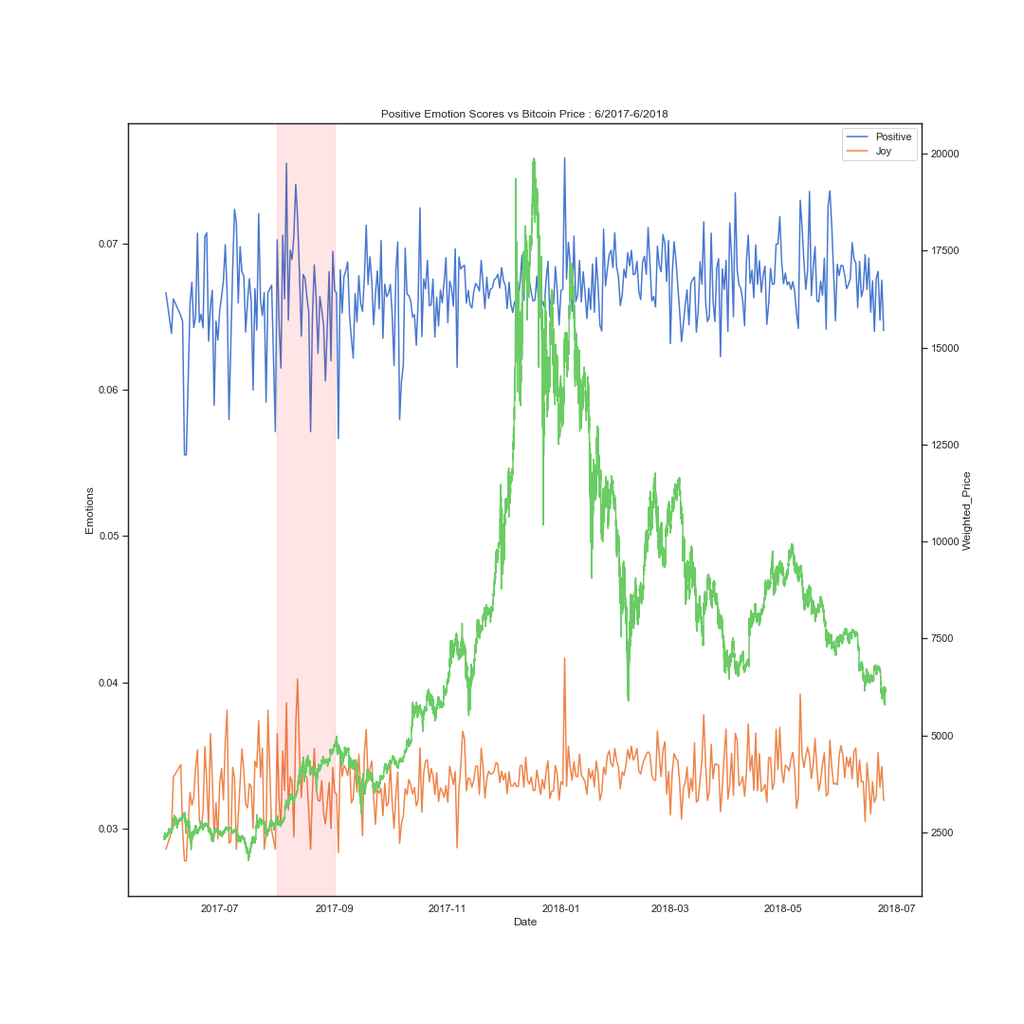

```python
from IPython.display import Image
Image(filename="Positive-BitcoinPrice.png",height=800,width=800)
```

# Note:

## Although the general positive trend cannot explicitly state the sudden rise in the BitCoin Prices, one may notice price increase is often preceded by an increase in Positive Comments in Reddit

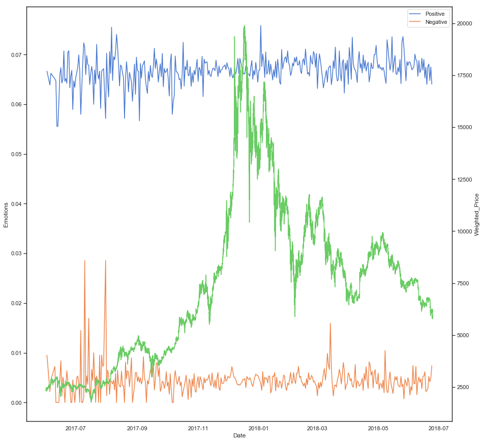

```python
# @hidden_cell
#Plotting difference in emotions with bitcoin price

import seaborn as sns
sns.set(style="darkgrid")
import matplotlib.pyplot as plt

emotions = ['Positive','Negative']

plt.figure(figsize=(15,15))

sns.set(style="white", palette="muted", color_codes=True)

for i in emotions:
    sns.lineplot(x="Date", y=i,
                 data=time_series_analysis1)
plt.legend(emotions)
plt.ylabel('Emotions')
ax2 = plt.twinx()

sns.lineplot(x="date", y="Weighted_Price",
             data=btc_all1,color='g')

plt.xlabel('TimeStamps')


plt.show()
```

## 'Negative' Emotion against Bitcoin Price % changes

### Find Bitcoin Percentage Change

```python
btc_all2=btc_all1[['date','Weighted_Price']]
btc_all2.set_index('date',inplace=True)
btc_all_pct_change = btc_all2.pct_change(periods=10000)
```

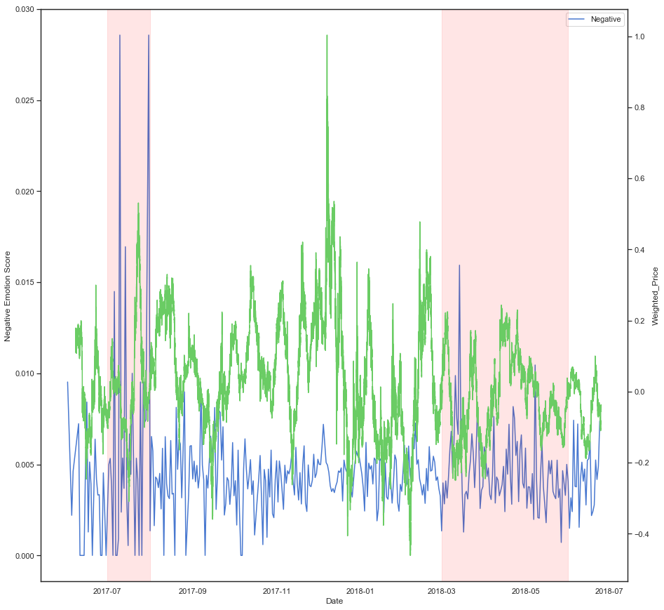

```python
#Plotting difference in emotions with bitcoin price
import seaborn as sns
sns.set(style="darkgrid")
import matplotlib.pyplot as plt


emotions = ['Negative']

plt.figure(figsize=(15,15))

sns.set(style="white", palette="muted", color_codes=True)

for i in emotions:
    sns.lineplot(x="Date", y=i,
                 data=time_series_analysis1)
plt.legend(emotions)
plt.ylabel('Negative Emotion Score')
ax2 = plt.twinx()

sns.lineplot(x="date", y="Weighted_Price",
             data=btc_all_pct_change.reset_index(),color='g')

plt.xlabel('TimeStamps')
plt.axvspan('2017-07-01', '2017-08-01', color='red', alpha=0.1)
plt.axvspan('2018-03-01', '2018-06-01', color='red', alpha=0.1)

plt.show()
```

## 'Positive' Emotion against Bitcoin Price % changes

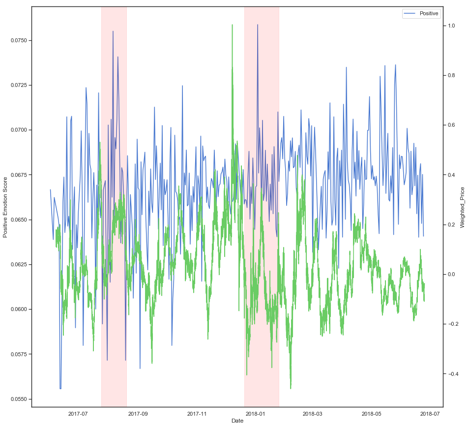

```python
#Plotting difference in emotions with bitcoin price

import seaborn as sns
sns.set(style="darkgrid")
import matplotlib.pyplot as plt

emotions = ['Positive']

plt.figure(figsize=(15,15))

sns.set(style="white", palette="muted", color_codes=True)

for i in emotions:
    sns.lineplot(x="Date", y=i,
                 data=time_series_analysis1)
plt.legend(emotions)
plt.ylabel('Positive Emotion Score')
ax2 = plt.twinx()

sns.lineplot(x="date", y="Weighted_Price",
             data=btc_all_pct_change.reset_index(),color='g')

plt.xlabel('TimeStamps')
plt.axvspan('2017-07-25', '2017-08-20', color='red', alpha=0.1)
plt.axvspan('2017-12-20', '2018-01-25', color='red', alpha=0.1)

plt.show()
```

## To Further identify correlation for Negative Emotions, we narrow down the window to 2017/7 and 2017/8

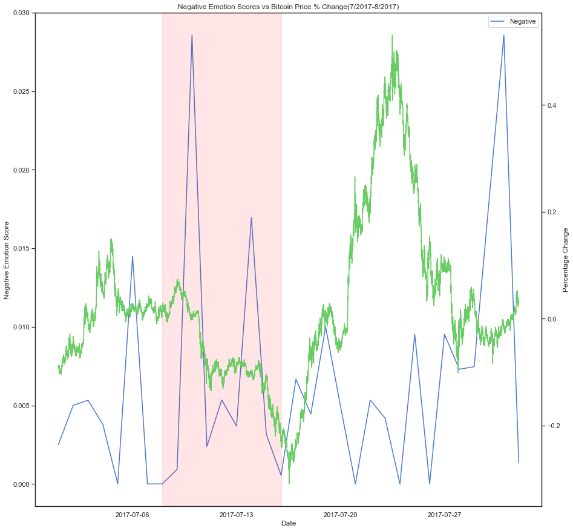

```python
negative_timeseries=time_series_analysis1[time_series_analysis1['Date']>='2017-07-01']
negative_timeseries=negative_timeseries[negative_timeseries['Date']<='2017-08-01']

btc_all_pct_change1=btc_all_pct_change.reset_index()

negative_bitcoin_range = btc_all_pct_change1[btc_all_pct_change1['date']>='2017-07-01']
negative_bitcoin_range= negative_bitcoin_range[negative_bitcoin_range['date']<='2017-08-01']


#negative_bitcoin_range.dropna(how='any')

emotions = ['Negative']

plt.figure(figsize=(15,15))

sns.set(style="white", palette="muted", color_codes=True)

for i in emotions:
    sns.lineplot(x="Date", y=i,
                 data=negative_timeseries)
plt.legend(emotions)
plt.ylabel('Negative Emotion Score')
ax2 = plt.twinx()

sns.lineplot(x="date", y="Weighted_Price",
             data=negative_bitcoin_range.reset_index(),color='g')
plt.ylabel('Percentage Change')
plt.xlabel('Reduced TimeStamps')
plt.axvspan('2017-07-08', '2017-07-16', color='red', alpha=0.1)
# plt.axvspan('2018-03-01', '2018-06-01', color='red', alpha=0.1)
plt.title('Negative Emotion Scores vs Bitcoin Price % Change(7/2017-8/2017)')
plt.savefig('Negative-BitcoinPricePercent.png')
plt.show()
```

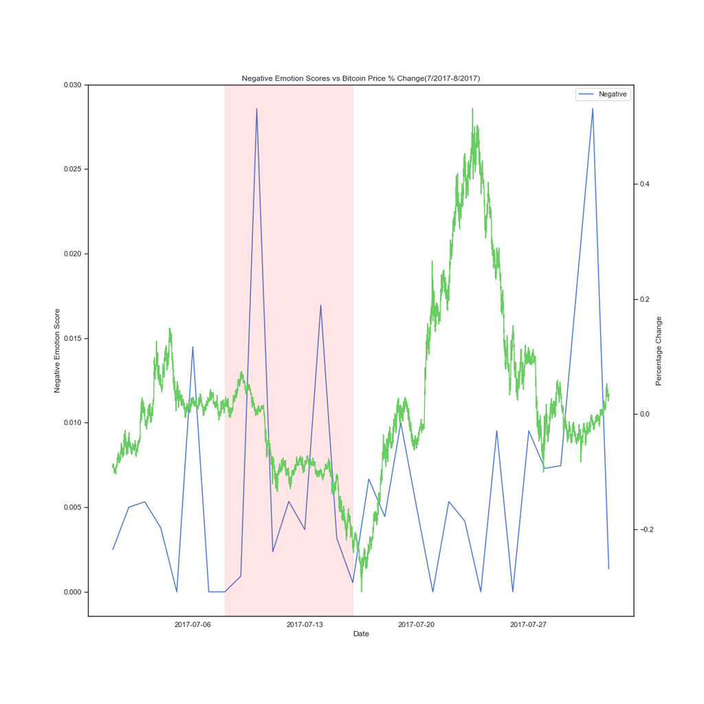

```python
from IPython.display import Image
Image(filename="Negative-BitcoinPricePercent.png",height=800,width=800)
```

### Plot Word Cloud where the % change is maximum against Negative Sentiments

```python
dfn=df[df['Date']>='2017-07-7']
dfn=dfn[dfn['Date']<='2017-08-16']
```

```
(-0.5, 9999.5, 9999.5, -0.5)
```

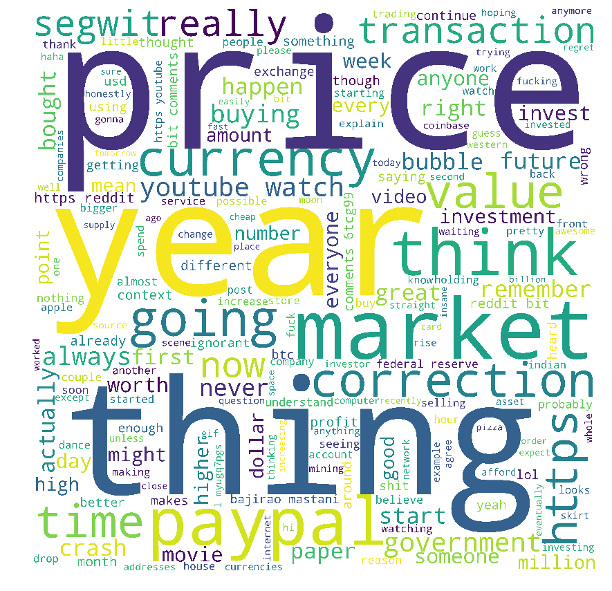

```python
import pandas as pd
import matplotlib.pyplot as plt
%matplotlib inline
from wordcloud import WordCloud, STOPWORDS

MIN_LENGTH=5
DELETE_WORDS=['coinbase','crypto','world','like','let','went','till','kinda','bitcoin','coin','people','money']

def remove_words(text_string,DELETE_WORDS=DELETE_WORDS):
    for word in DELETE_WORDS:
        text_string = text_string.replace(word,' ')
    return text_string

def remove_short_words(text_string,min_length = MIN_LENGTH):
    word_list = text_string.split()
    for word in word_list:
        if len(word) < min_length:
            text_string = text_string.replace(' '+word+' ',' ',1)
    return text_string


# string together all comments from 'body' columns to prepare for Word Cloud
all_comments = ''
for comment in dfn['body']:
    comment = remove_words(comment)
    comment = remove_short_words(comment)
    comment = comment.lower()
    if comment in STOPWORDS:
            comment = comment.replace(comment,'')
    all_comments=all_comments+'. '+str(comment)

# create WordCloud
from wordcloud import WordCloud, STOPWORDS
import matplotlib.pyplot as plt
%matplotlib inline

plt.figure(figsize=(15,15))

wordcloud = WordCloud(stopwords=STOPWORDS,background_color='white',width=10000,height=10000).generate(all_comments)

plt.imshow(wordcloud)
plt.axis('off')
```

## Create the Corpus

```python
import nltk
nltk.download('wordnet')
from nltk import sent_tokenize, word_tokenize
from gensim import corpora
from gensim.models.ldamodel import LdaModel
from gensim.parsing.preprocessing import STOPWORDS
import pprint
import gensim
from gensim.utils import simple_preprocess
from nltk.stem import WordNetLemmatizer, SnowballStemmer
from nltk.stem.porter import *
import pandas as pd
import numpy as np


stemmer = SnowballStemmer('english')
def lemmatize_stemming(text):
    return stemmer.stem(WordNetLemmatizer().lemmatize(text, pos='v'))
def preprocess(text):
    result = []
    for token in gensim.utils.simple_preprocess(text):
        if token not in gensim.parsing.preprocessing.STOPWORDS and len(token) > 4:
            result.append(lemmatize_stemming(token))
    return result
```

```python
string=list()

for i in range(len(dfn)):
    t=str(dfn['body'].iloc[i])
    stemedText=preprocess(t)
    string.extend(stemedText)

description=''

for i in string:
    description+=' '+i
```

```python
# Add additional stopwords that do not add meaningful conclusion (e.g. price)
STOPWORDS_ADDITIONAL = ['reddit','happen','video','valu','wallet','govern','transact','start','watch','https','peopl','invest','correct','currenc','remember','new','long','correction','buy','good','market','use','want','years','think','time','price','know','btc','sell','going','coinbase','crypto','world','like','let','went','till','kinda','bitcoin','coin','people','money','thing','year']

# Prepare text, dictionary and corpus
texts = [[word for word in description.split()
        if word not in STOPWORDS and word.isalnum() and len(word)>3 and not word.lower() in STOPWORDS_ADDITIONAL]]

dictionary = corpora.Dictionary(texts) #(word_id,frequency) pairs
corpus = [dictionary.doc2bow(text) for text in texts]
```

```python
#Set parameters
num_topics = 1
passes = 10

lda = LdaModel(corpus,
              id2word=dictionary,
              num_topics=num_topics,
              passes=passes)

pp = pprint.PrettyPrinter(indent=4)
pp.pprint(lda.print_topics(num_words=8))
```

```
[   (   0,
        '0.006*"youtub" + 0.005*"comment" + 0.005*"remindm" + 0.005*"segwit" + '
        '0.004*"right" + 0.004*"bank" + 0.004*"exchang" + 0.004*"actual"')]
```

```python
from wordcloud import WordCloud, STOPWORDS

def draw_wordcloud(lda,topicnum,min_size=0,STOPWORDS=[]):
    word_list=[]
    prob_total = 0
    for word,prob in lda.show_topic(topicnum,topn=50):
        prob_total +=prob
    for word,prob in lda.show_topic(topicnum,topn=50):
        if word in STOPWORDS or  len(word) < min_size:
            continue
        freq = int(prob/prob_total*1000)
        alist=[word]
        word_list.extend(alist*freq)

    from wordcloud import WordCloud, STOPWORDS
    import matplotlib.pyplot as plt
    %matplotlib inline
    from random import shuffle
    shuffle(word_list)
    text = ' '.join(word_list)
    wordcloud = WordCloud(stopwords=STOPWORDS,background_color='white',max_words=20).generate(text)

    plt.axis('off')
    plt.imshow(wordcloud)

    return None
```

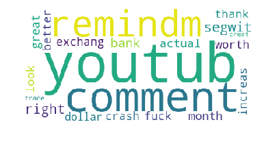

```python
#Let's see if we can identify words that may help point the negative trend

draw_wordcloud(lda,0)
```

## To Further identify correlation for Positive Emotions, we narrow down the window to 2017/12 and 2018/02

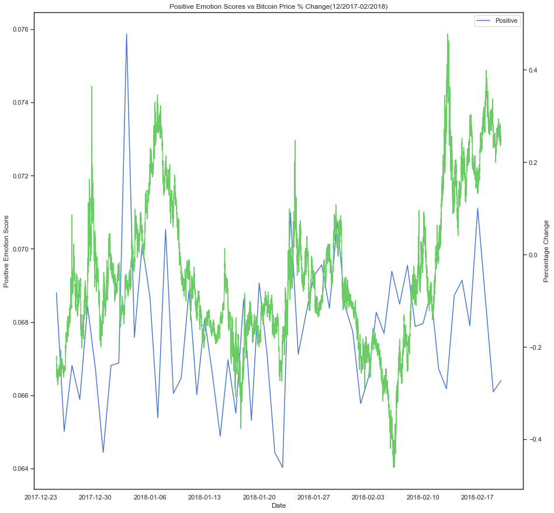

```python
positive_timeseries=time_series_analysis1[time_series_analysis1['Date']>='2017-12-25']
positive_timeseries=positive_timeseries[positive_timeseries['Date']<='2018-02-20']

btc_all_pct_change1=btc_all_pct_change.reset_index()

positive_bitcoin_range = btc_all_pct_change1[btc_all_pct_change1['date']>='2017-12-25']
positive_bitcoin_range= positive_bitcoin_range[positive_bitcoin_range['date']<='2018-02-20']


# positive_pct_change.dropna(how='any')

emotions = ['Positive']

plt.figure(figsize=(15,15))

sns.set(style="white", palette="muted", color_codes=True)

for i in emotions:
    sns.lineplot(x="Date", y=i,
                 data=positive_timeseries)
plt.legend(emotions)
plt.ylabel('Positive Emotion Score')
ax2 = plt.twinx()

sns.lineplot(x="date", y="Weighted_Price",
             data=positive_bitcoin_range.reset_index(),color='g')
plt.ylabel('Percentage Change')
plt.xlabel('Reduced TimeStamps')
# plt.axvspan('2018-01-22', '2018-01-16', color='red', alpha=0.1)
# plt.axvspan('2018-03-01', '2018-06-01', color='red', alpha=0.1)
plt.title('Positive Emotion Scores vs Bitcoin Price % Change(12/2017-02/2018)')
plt.savefig('Positive-BitcoinPricePercent.png')
plt.show()
```

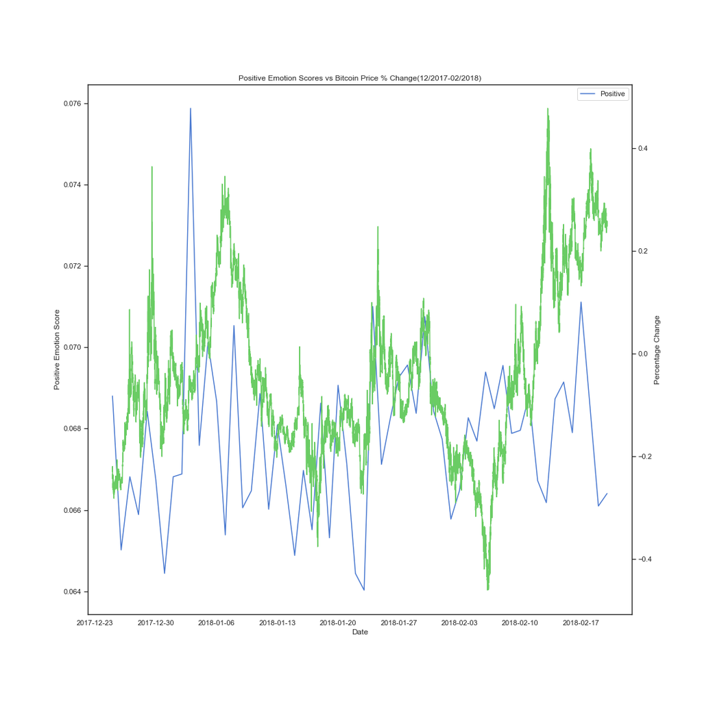

```python
from IPython.display import Image
Image(filename="Positive-BitcoinPricePercent.png",height=800,width=800)
```

### Plot Word Cloud where the % change is maximum against Positive Sentiments

```python
dfp=df[df['Date']>='2017-12-30']
dfp=dfp[dfp['Date']<='2018-01-10']
```

```
(-0.5, 9999.5, 9999.5, -0.5)
```

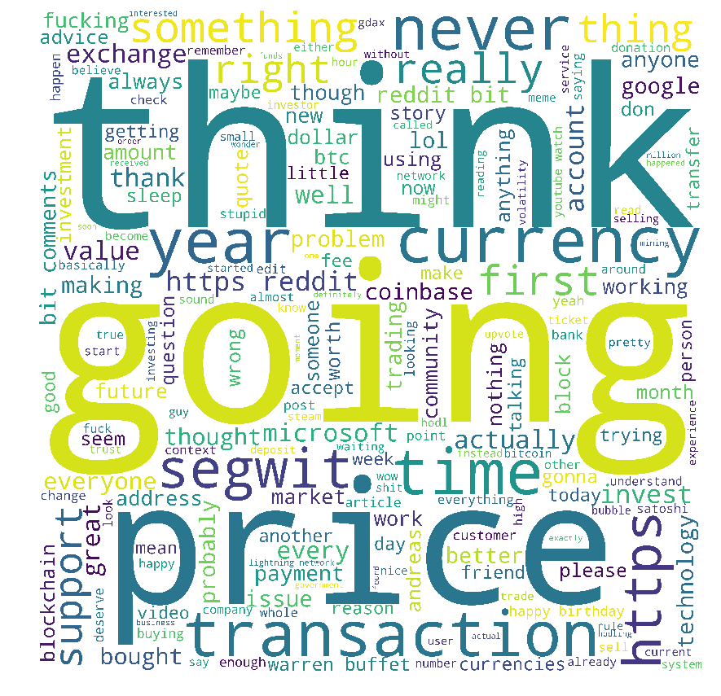

```python
import pandas as pd
import matplotlib.pyplot as plt
%matplotlib inline
from wordcloud import WordCloud, STOPWORDS

MIN_LENGTH=5
DELETE_WORDS=['coinbase','crypto','world','like','let','went','till','kinda','bitcoin','coin','people','money']

def remove_words(text_string,DELETE_WORDS=DELETE_WORDS):
    for word in DELETE_WORDS:
        text_string = text_string.replace(word,' ')
    return text_string

def remove_short_words(text_string,min_length = MIN_LENGTH):
    word_list = text_string.split()
    for word in word_list:
        if len(word) < min_length:
            text_string = text_string.replace(' '+word+' ',' ',1)
    return text_string


# string together all comments from 'body' columns to prepare for Word Cloud
all_comments = ''
for comment in dfp['body']:
    comment = remove_words(comment)
    comment = remove_short_words(comment)
    comment = comment.lower()
    if comment in STOPWORDS:
            comment = comment.replace(comment,'')
    all_comments=all_comments+'. '+str(comment)

# create WordCloud
from wordcloud import WordCloud, STOPWORDS
import matplotlib.pyplot as plt
%matplotlib inline

plt.figure(figsize=(15,15))

wordcloud = WordCloud(stopwords=STOPWORDS,background_color='white',width=10000,height=10000).generate(all_comments)

plt.imshow(wordcloud)
plt.axis('off')
```

## Let's see if we can identify the reasons for increase in the price of the Bitcoin that is being driven by the positive sentiments

```python
import nltk
nltk.download('wordnet')
from nltk import sent_tokenize, word_tokenize
from gensim import corpora
from gensim.models.ldamodel import LdaModel
from gensim.parsing.preprocessing import STOPWORDS
import pprint
import gensim
from gensim.utils import simple_preprocess
from nltk.stem import WordNetLemmatizer, SnowballStemmer
from nltk.stem.porter import *
import pandas as pd
import numpy as np


stemmer = SnowballStemmer('english')
def lemmatize_stemming(text):
    return stemmer.stem(WordNetLemmatizer().lemmatize(text, pos='v'))
def preprocess(text):
    result = []
    for token in gensim.utils.simple_preprocess(text):
        if token not in gensim.parsing.preprocessing.STOPWORDS and len(token) > 4:
            result.append(lemmatize_stemming(token))
    return result
```

```python
string=list()

for i in range(len(dfp)):
    t=str(dfp['body'].iloc[i])
    stemedText=preprocess(t)
    string.extend(stemedText)

description=''

for i in string:
    description+=' '+i
```

```python
# Add additional stopwords that do not add meaningful conclusion (e.g. price)
STOPWORDS_ADDITIONAL = ['reddit','happen','video','valu','wallet','govern','transact','start','watch','https','peopl','invest','correct','currenc','remember','new','long','correction','buy','good','market','use','want','years','think','time','price','know','btc','sell','going','coinbase','crypto','world','like','let','went','till','kinda','bitcoin','coin','people','money','thing','year']

# Prepare text, dictionary and corpus
texts = [[word for word in description.split()
        if word not in STOPWORDS and word.isalnum() and len(word)>3 and not word.lower() in STOPWORDS_ADDITIONAL]]

dictionary = corpora.Dictionary(texts) #(word_id,frequency) pairs
corpus = [dictionary.doc2bow(text) for text in texts]
```

```python
#Set parameters
num_topics = 1
passes = 10

lda = LdaModel(corpus,
              id2word=dictionary,
              num_topics=num_topics,
              passes=passes)

pp = pprint.PrettyPrinter(indent=4)
pp.pprint(lda.print_topics(num_words=8))
```

```
[   (   0,
        '0.006*"segwit" + 0.006*"support" + 0.005*"coinbas" + 0.005*"comment" '
        '+ 0.005*"actual" + 0.004*"work" + 0.004*"payment" + 0.004*"account"')]
```

```python
from wordcloud import WordCloud, STOPWORDS

def draw_wordcloud(lda,topicnum,min_size=0,STOPWORDS=[]):
    word_list=[]
    prob_total = 0
    for word,prob in lda.show_topic(topicnum,topn=50):
        prob_total +=prob
    for word,prob in lda.show_topic(topicnum,topn=50):
        if word in STOPWORDS or  len(word) < min_size:
            continue
        freq = int(prob/prob_total*1000)
        alist=[word]
        word_list.extend(alist*freq)

    from wordcloud import WordCloud, STOPWORDS
    import matplotlib.pyplot as plt
    %matplotlib inline
    from random import shuffle
    shuffle(word_list)
    text = ' '.join(word_list)
    wordcloud = WordCloud(stopwords=STOPWORDS,background_color='white',max_words=20).generate(text)

    plt.axis('off')
    plt.imshow(wordcloud)

    return None
```

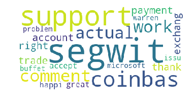

```python
draw_wordcloud(lda,0)
```